# ANALISIS DATASET HOUSES

JGB1970

2022-08-31

```r
library(dplyr)
library(tidyr)
library(ggplot2)
library(performance)
library(moments)
library(RColorBrewer)
library(fastDummies)
library(glmnet)
library(ISLR)
library(recipes)
library(rsample)
library(glmnetUtils)
library(caret)
library(openxlsx)
library(writexl)
library(corrplot)
library(car)
library(olsrr)
library(GGally)
library(MASS)
library(tseries)
library(naniar)
library(ggpubr)
library(broom)
library(lmtest)
library(leaps)
library(recipes)
select <- dplyr::select
library(circlize)
library(FactoMineR)
library(factoextra)
```

# INTRODUCCIÓN

Voy a analizar el precio de las casas en King County. Haré un breve repaso a los campos del dataset:

id es un campo de identificación único de la casa en cuestión  
date: Fecha en la que se vendió  
price: Precio de venta  
bedrooms: número de habitaciones  
bathrooms: Número de baños  
sqft_living: m2 cubiertos  
sqft_lot: m2 totales de la finca  
floors: número de pisos  
waterfront: booleano de vistas al mar o no.  
view: Calificación de 0 a 4 de las vistas que tiene  
condition: Estado de la casa, de 1 a 5.  
grade: Calificación de los materiales con los que se ha construido la casa.  
sqft_above: Metros cuadrados sobre la superficie  
sqft_basement: Metros del sótano  
yr_built: Año construcción  
yr_renovated: Año de renovación  
zipcode: código postal  
lat: Latitud  
long: Longitud  
sqft_liv15: Media de los metros cuadrados cubiertos de las 15 casas más cercanas  
sqft_lot15: Media de los metros cuadrados de la finca de las 15 casas más cercanas  
Los campos id y Date los voy a desechar: no aportan información al modelo de regresión que se quiere diseñar (el primero es un identificador y el segundo una fecha que en principio obviamos para centrarnos en el análisis sin su vertiente temporal. El campo bathrooms aparece como un campo continuo, no tiene mucho sentido, lo voy a convertir en integer (haré lo mismo con floors). Aunque analizaremos más tarde las correlaciones, los campos sqft_above y sqft_basement suman el total de sqft_living. Echándole un vistazo al summary y al dataset, podemos observar que algunas propiedades no tienen baño, otras no tienen habitaciones, y en varios casos, ni lo uno ni lo otro (además suponen registros extremos que pueden afectar al modelo).

Hay variables como condition, grade, yr_built, que presentan pocos registros para determinados niveles de clasificación. Esto me ha generado problemas sobre todo en el PCA. La solución que he adoptado ha sido la reclasificación de los valores mediante la función tile o sumando los escasos registros de alguna categoría a la categoría adyacente.

A mi modo de ver, el precio de las casas viene determinado por dos factores principales: sus características y su localización. En este dataset, la localización se puede analizar por medio de la latitud y la longitud, o por el código postal (método más arbitrario); las características de la casa vienen reflejadas en el resto de campos.

# ESTUDIO DEL DATASET

## Summary y Nas:

```r
df <- read.csv("C:\\Users\\JULIAN\\Desktop\\CLASES DE R\\EJERCICIOS CLASE\\clases\\data\\kc_house_data.csv")
df <- df %>% select(everything(), -id,-date)
df$bathrooms <-  as.integer(df$bathrooms)
df$floors <-  as.integer(df$floors)
summary(df)
```

```
##      price            bedrooms        bathrooms     sqft_living
##  Min.   :  75000   Min.   : 0.000   Min.   :0.00   Min.   :  290
##  1st Qu.: 321950   1st Qu.: 3.000   1st Qu.:1.00   1st Qu.: 1427
##  Median : 450000   Median : 3.000   Median :2.00   Median : 1910
##  Mean   : 540088   Mean   : 3.371   Mean   :1.75   Mean   : 2080
##  3rd Qu.: 645000   3rd Qu.: 4.000   3rd Qu.:2.00   3rd Qu.: 2550
##  Max.   :7700000   Max.   :33.000   Max.   :8.00   Max.   :13540
##     sqft_lot           floors        waterfront            view
##  Min.   :    520   Min.   :1.000   Min.   :0.000000   Min.   :0.0000
##  1st Qu.:   5040   1st Qu.:1.000   1st Qu.:0.000000   1st Qu.:0.0000
##  Median :   7618   Median :1.000   Median :0.000000   Median :0.0000
##  Mean   :  15107   Mean   :1.446   Mean   :0.007542   Mean   :0.2343
##  3rd Qu.:  10688   3rd Qu.:2.000   3rd Qu.:0.000000   3rd Qu.:0.0000
##  Max.   :1651359   Max.   :3.000   Max.   :1.000000   Max.   :4.0000
##    condition         grade          sqft_above   sqft_basement
##  Min.   :1.000   Min.   : 1.000   Min.   : 290   Min.   :   0.0
##  1st Qu.:3.000   1st Qu.: 7.000   1st Qu.:1190   1st Qu.:   0.0
##  Median :3.000   Median : 7.000   Median :1560   Median :   0.0
##  Mean   :3.409   Mean   : 7.657   Mean   :1788   Mean   : 291.5
##  3rd Qu.:4.000   3rd Qu.: 8.000   3rd Qu.:2210   3rd Qu.: 560.0
##  Max.   :5.000   Max.   :13.000   Max.   :9410   Max.   :4820.0
##     yr_built     yr_renovated       zipcode           lat
##  Min.   :1900   Min.   :   0.0   Min.   :98001   Min.   :47.16
##  1st Qu.:1951   1st Qu.:   0.0   1st Qu.:98033   1st Qu.:47.47
##  Median :1975   Median :   0.0   Median :98065   Median :47.57
##  Mean   :1971   Mean   :  84.4   Mean   :98078   Mean   :47.56
##  3rd Qu.:1997   3rd Qu.:   0.0   3rd Qu.:98118   3rd Qu.:47.68
##  Max.   :2015   Max.   :2015.0   Max.   :98199   Max.   :47.78
##       long        sqft_living15    sqft_lot15
##  Min.   :-122.5   Min.   : 399   Min.   :   651
##  1st Qu.:-122.3   1st Qu.:1490   1st Qu.:  5100
##  Median :-122.2   Median :1840   Median :  7620
##  Mean   :-122.2   Mean   :1987   Mean   : 12768
##  3rd Qu.:-122.1   3rd Qu.:2360   3rd Qu.: 10083
##  Max.   :-121.3   Max.   :6210   Max.   :871200
```

No hay NAs.

```r
df %>%
  summarise_all(.funs = ~ mean(is.na(.)))
```

| price | bedrooms | bathrooms | sqft_living | sqft_lot | floors | waterfront | view | condition | grade | sqft_above | sqft_basement | yr_built | yr_renovated | zipcode | lat | long | sqft_living15 | sqft_lot15 |
| --- | --- | --- | --- | --- | --- | --- | --- | --- | --- | --- | --- | --- | --- | --- | --- | --- | --- | --- |
| 0 | 0 | 0 | 0 | 0 | 0 | 0 | 0 | 0 | 0 | 0 | 0 | 0 | 0 | 0 | 0 | 0 | 0 | 0 |

## Análisis de las variables:

### Numéricas:

Como podemos observar a continuación, todas las variables son numéricas, pero algunas de ellas son nominales y habrá que tenerlo en cuenta a la hora de diseñar los modelos para aprovechar la información que suministran y para que los algoritmos no las traten como valores continuos. Es el caso de grade, condition, waterfront, zipcode…

```r
str(df)
```

```
## 'data.frame':    21613 obs. of  19 variables:
##  $ price        : num  221900 538000 180000 604000 510000 ...
##  $ bedrooms     : int  3 3 2 4 3 4 3 3 3 3 ...
##  $ bathrooms    : int  1 2 1 3 2 4 2 1 1 2 ...
##  $ sqft_living  : int  1180 2570 770 1960 1680 5420 1715 1060 1780 1890 ...
##  $ sqft_lot     : int  5650 7242 10000 5000 8080 101930 6819 9711 7470 6560 ...
##  $ floors       : int  1 2 1 1 1 1 2 1 1 2 ...
##  $ waterfront   : int  0 0 0 0 0 0 0 0 0 0 ...
##  $ view         : int  0 0 0 0 0 0 0 0 0 0 ...
##  $ condition    : int  3 3 3 5 3 3 3 3 3 3 ...
##  $ grade        : int  7 7 6 7 8 11 7 7 7 7 ...
##  $ sqft_above   : int  1180 2170 770 1050 1680 3890 1715 1060 1050 1890 ...
##  $ sqft_basement: int  0 400 0 910 0 1530 0 0 730 0 ...
##  $ yr_built     : int  1955 1951 1933 1965 1987 2001 1995 1963 1960 2003 ...
##  $ yr_renovated : int  0 1991 0 0 0 0 0 0 0 0 ...
##  $ zipcode      : int  98178 98125 98028 98136 98074 98053 98003 98198 98146 98038 ...
##  $ lat          : num  47.5 47.7 47.7 47.5 47.6 ...
##  $ long         : num  -122 -122 -122 -122 -122 ...
##  $ sqft_living15: int  1340 1690 2720 1360 1800 4760 2238 1650 1780 2390 ...
##  $ sqft_lot15   : int  5650 7639 8062 5000 7503 101930 6819 9711 8113 7570 ...
```

Paso a ver ahora las distribuciones de las variables:

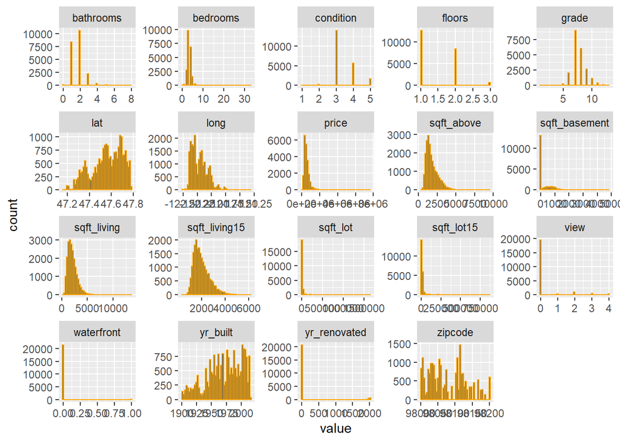

```r
  df %>%
  select(where(is.numeric)) %>%
  pivot_longer(everything()) %>%
  ggplot() +
  geom_histogram(aes(x = value), color ='orange' , bins= 50) +
  facet_wrap(~ name, scales = "free")
```

#### La variable objetivo: Price

En principio, la variable objetivo, que es price, no presenta una figura simétrica y sí muchos outliers.

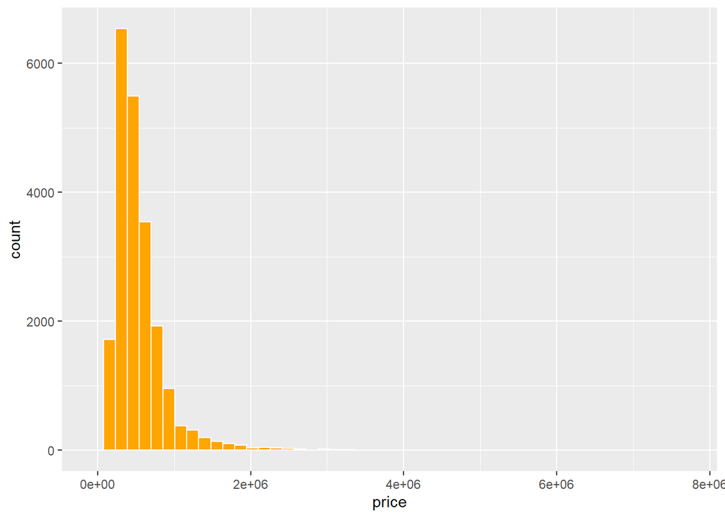

```r
df %>%
  ggplot() +
  geom_histogram(aes(x = price, y =stat(count)), color ='white', fill= "orange" , bins= 50)
```

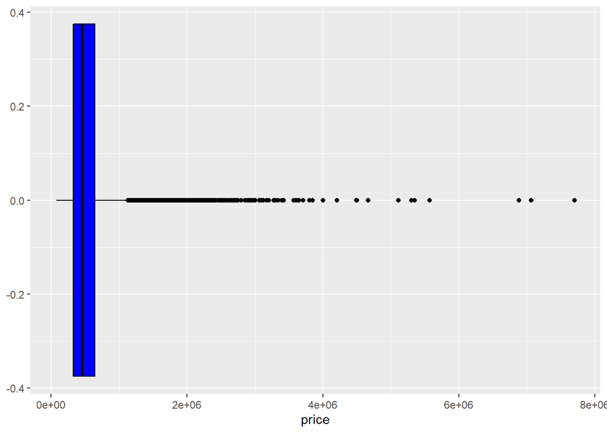

```r
df %>%
  ggplot() +
  geom_boxplot(aes(x = price), color ='black', fill= "blue" )
```

Debido al número de registros, no puedo aplicar un test de Saphiro, pero si Jarque Bera.

```r
  jarque.bera.test(df$price)
```

```
##
##  Jarque Bera Test
##
## data:  df$price
## X-squared = 1134998, df = 2, p-value < 2.2e-16
```

Rechazamos la hipótesis nula de normalidad por el bajo valor del pvalue.

Vamos a probar a hacer transformaciones sobre esta variable para ver si podemos conseguir esa normalidad:

1) Le aplicaremos el logaritmo:

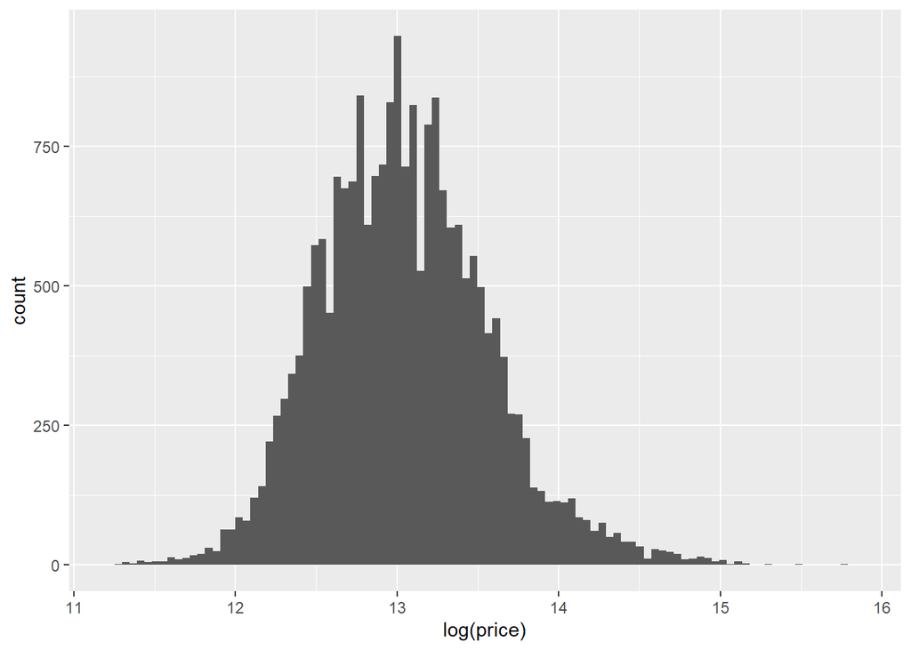

```r
        df %>%     ggplot( aes(log(price))) +
              geom_histogram(bins = 100)
```

El gráfico tiene mejor pinta:

```r
        log_price <-  log(df$price)
```

Sin embargo, el test dice que no es normal.

```r
         jarque.bera.test(log_price)
```

```
##
##  Jarque Bera Test
##
## data:  log_price
## X-squared = 1090.5, df = 2, p-value < 2.2e-16
```

En el gráfico qqnorm los puntos se separan en el tramo derecho de la línea

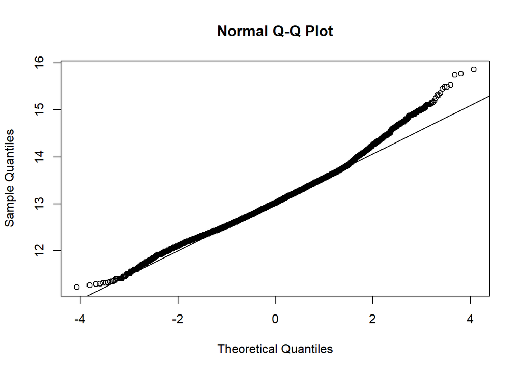

```r
         qqnorm(log_price)
         qqline(log_price)
```

2) Aplicamos Cox Box, el gráfico resulta más simétrico que el anterior.

```r
          data <-  df[, c("price", "bedrooms", "bathrooms", "sqft_living", "grade")]


          b <- boxcox(lm(data$price ~ 1))
```

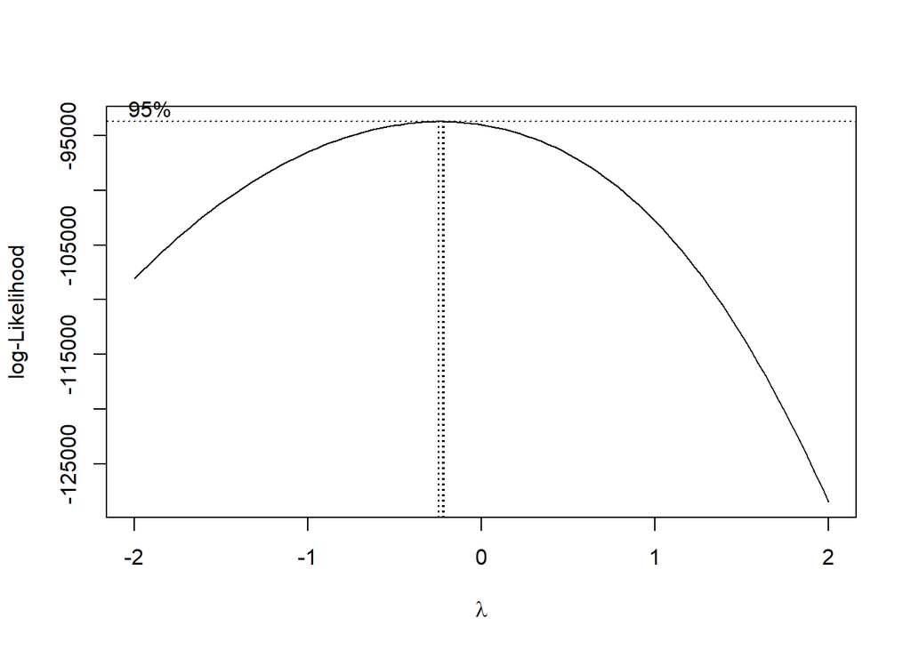

```r
          lambda <- b$x[which.max(b$y)]
          nuevo_price <- (df$price ^ lambda - 1) / lambda
          dfx <- cbind(df,  nuevo_price)
```

El parámetro landa sale cercano a 0, indica que la transformación apropiada es el logaritmo, pero modifico directamente los valores de la variable y los incluyo en una columna nueva.

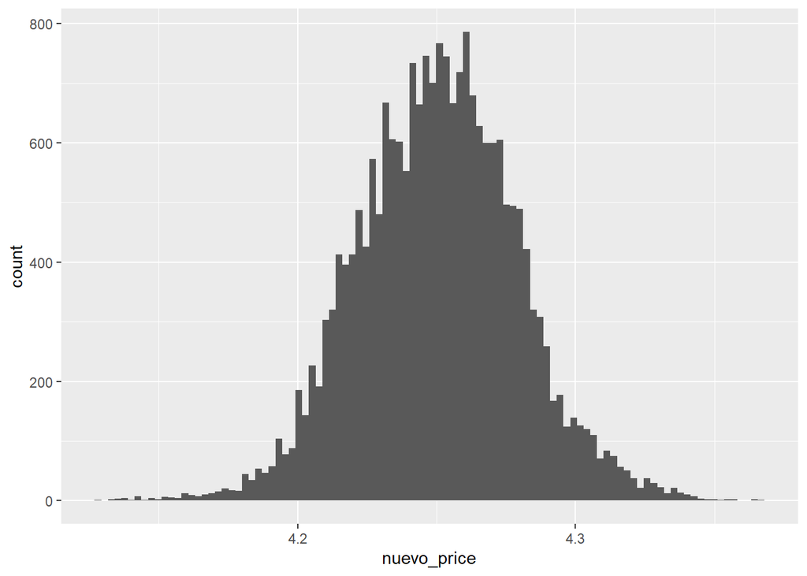

```r
          dfx %>%     ggplot( aes(nuevo_price)) +
            geom_histogram(bins = 100)
```

El test de Jarque Bera, sigue indicando que la variable no es normal

```r
          jarque.bera.test((nuevo_price))
```

```
##
##  Jarque Bera Test
##
## data:  (nuevo_price)
## X-squared = 89.915, df = 2, p-value < 2.2e-16
```

El gráfico qqnorm sale parecido. Aunque los tests digan lo contrario, el gráfico tiene apariencia normal.

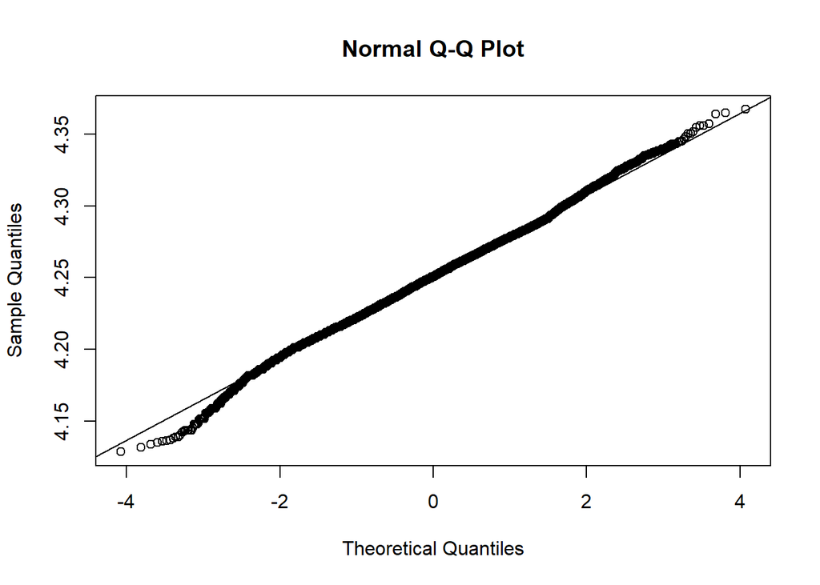

```r
          qqnorm(nuevo_price)
          qqline(nuevo_price)
```

#### La variable independiente sqft_living:

1) Aplicamos logaritmo:

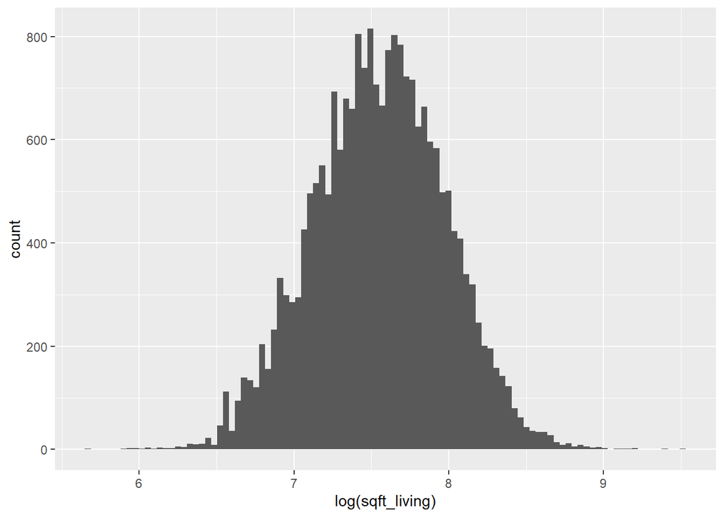

```r
         df %>%     ggplot( aes(log(sqft_living))) +
               geom_histogram(bins = 100)
```

El gráfico presenta simetria.

```r
        log_sqfeet_living <-  log(df$sqft_living)
```

Si el nivel de significancia fuera del 1%, estaríamos en la normalidad

```r
jarque.bera.test(log_sqfeet_living)
```

```
##
##  Jarque Bera Test
##
## data:  log_sqfeet_living
## X-squared = 7.2416, df = 2, p-value = 0.02676
```

El gráfico qqnorm sale casi perfecto.

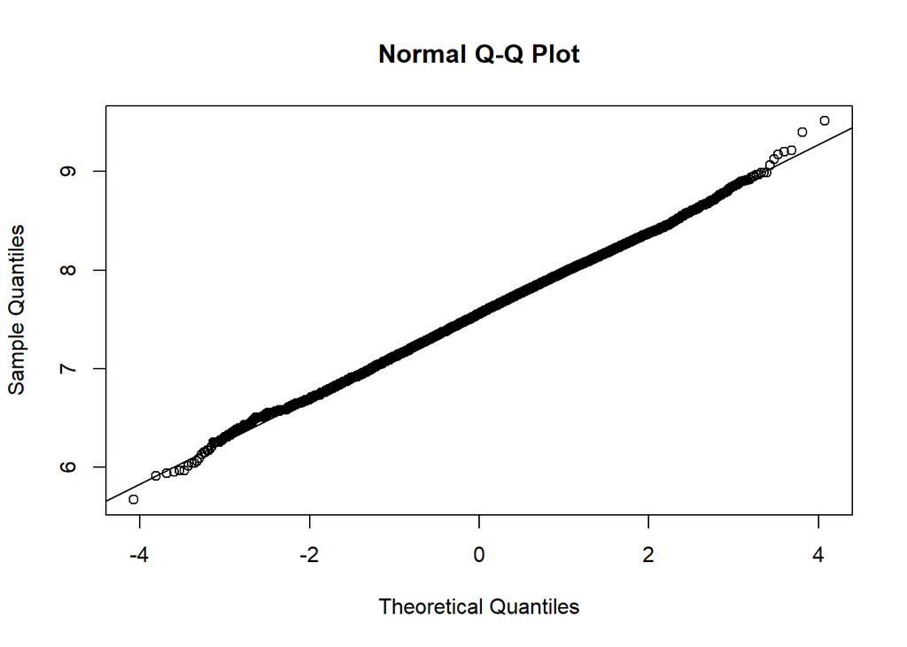

```r
qqnorm(log_sqfeet_living)
qqline(log_sqfeet_living)
```

2) Aplicamos Cox Box:  
El gráfico resulta más simétrico que el anterior

```r
data <-  df[, c("price", "bedrooms", "bathrooms", "sqft_living", "grade")]
b <- boxcox(lm(data$sqft_living ~ 1))
```

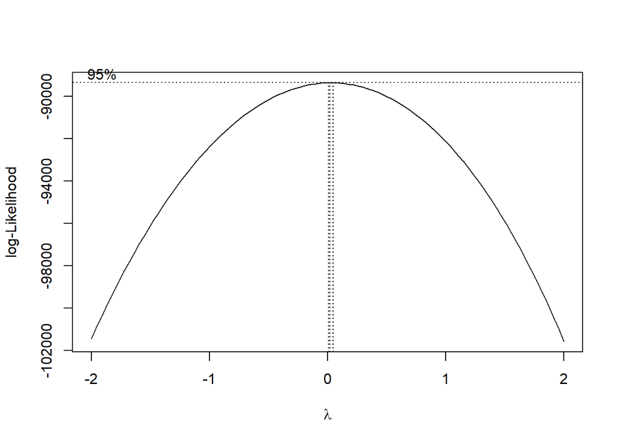

```r
lambda <- b$x[which.max(b$y)]
```

El parámetro landa sale cercano a 0, indica que la transformación apropiada es el logaritmo, pero modifico directamente los valores de la variable y los incluyo en una columna nueva.

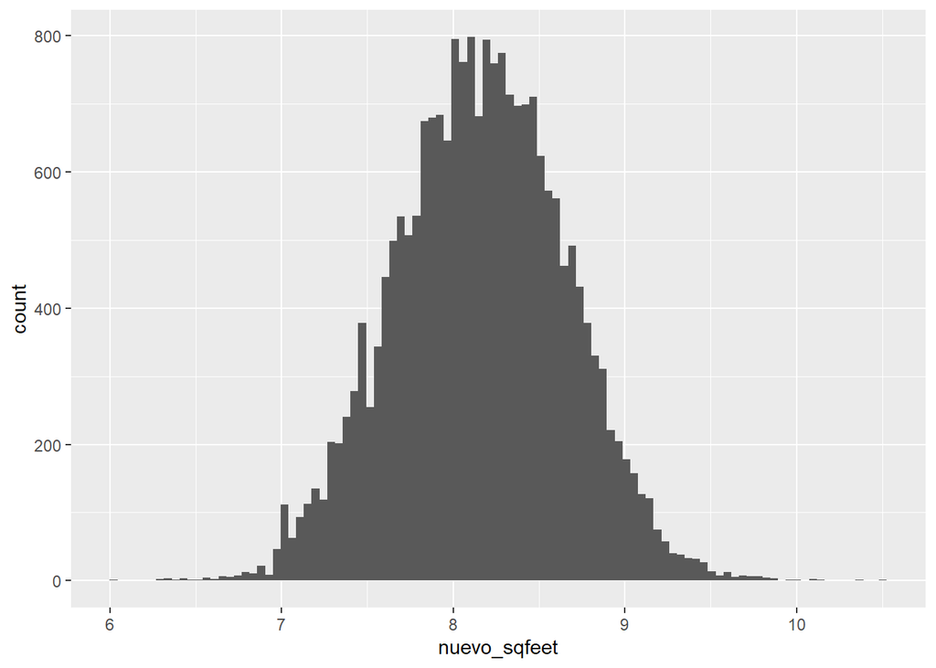

```r
nuevo_sqfeet <- (df$sqft_living ^ lambda - 1) / lambda
dfy <- cbind(df,  nuevo_sqfeet)
dfy %>%     ggplot( aes(nuevo_sqfeet)) +
  geom_histogram(bins = 100)
```

El test de Jarque Bera, la variable es normal.

```r
jarque.bera.test((nuevo_sqfeet))
```

```
##
##  Jarque Bera Test
##
## data:  (nuevo_sqfeet)
## X-squared = 2.8527, df = 2, p-value = 0.2402
```

El gráfico qqnorm es muy bueno.

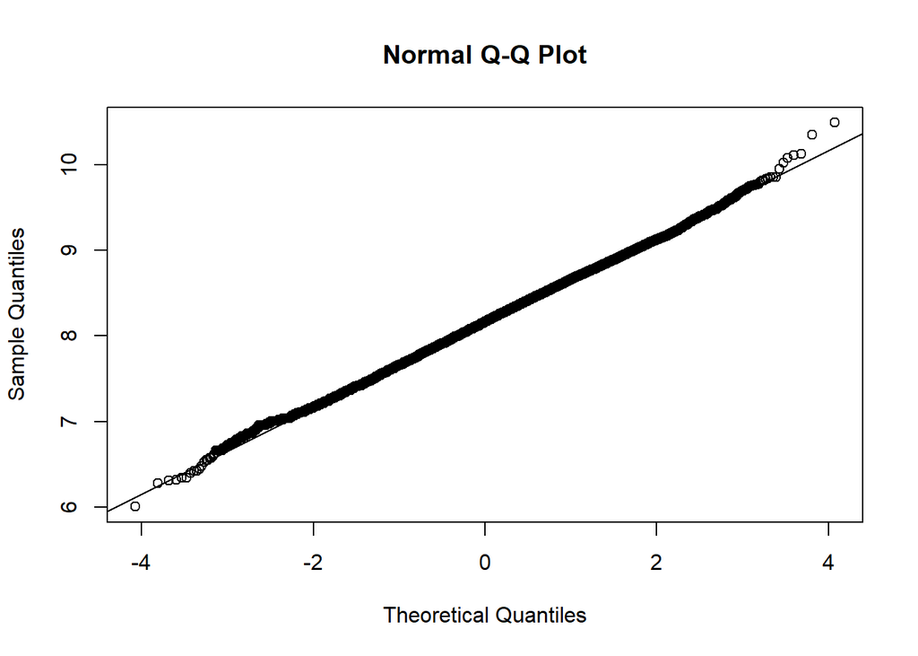

```r
qqnorm(nuevo_sqfeet)
qqline(nuevo_sqfeet)
```

### Latitud y longitud:

Aunque más adelante estudiaremos las correlaciones en profundidad, voy a analizar con más detalle la influencia de la localización de la casa en su valoración, a través de las variables longitud y latitud. Para ello, y para facilitar la visualización creo dos columnas nuevas: una en la que detallaré el precio por m2; en la otra clasificaré por deciles de cada uno de los registros.

```r
dfq <- df %>% mutate(mt = price/sqft_living)
dfq$clas <- ntile(dfq$mt, 10)
```

Aquí represento la interacción en varios gráficos.En este primer gráfico se muestran las casas según el decil en el que se encuentra su precio por metro cuadrado. Podemos observar (en negro y amarillo) donde se encuentran las propiedades más valiosas. Habrá que incluir latitud y longitud en los modelos a estudiar.

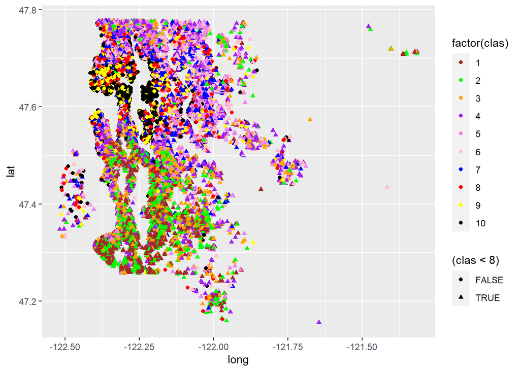

```r
dfq %>%
  select( mt,price, lat, long, zipcode,clas) %>%

  ggplot() +
  geom_point(aes(x = long, y =lat, color = factor(clas),  shape=(clas<8)) )+
  scale_colour_manual(values= c('brown', 'green', 'orange','purple', 'violet', 'pink', 'blue','red', 'yellow', 'black'))
```

En este segundo gráfico podemos ver claramente la diferenciación geográfica por precios, al seleccionar los deciles más y menos valiosos.

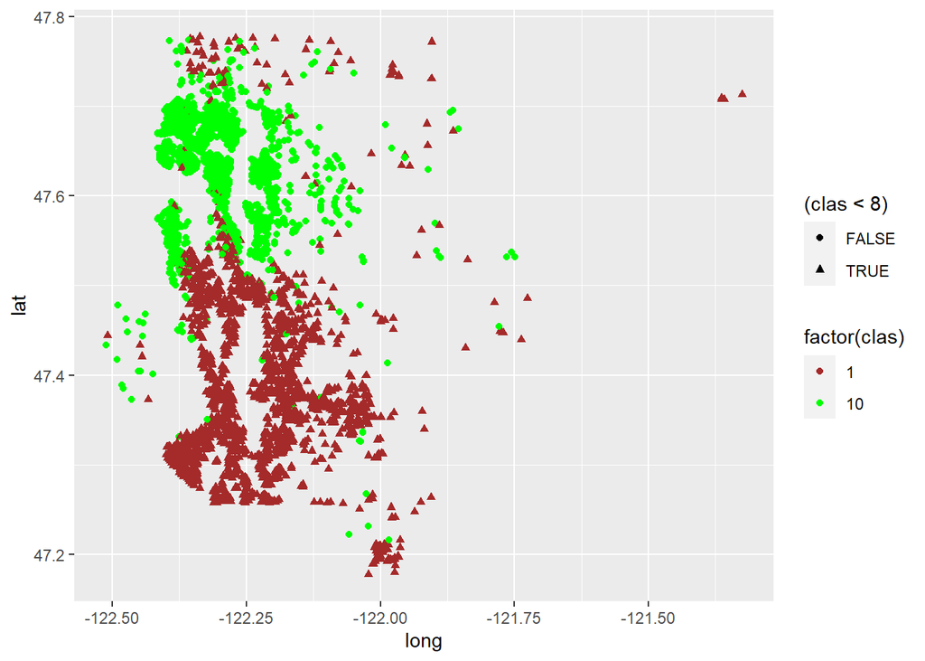

```r
dfq %>%
  select( mt,price, lat, long, zipcode,clas) %>%
  filter(clas==1 | clas== 10) %>%
  ggplot() +
  geom_point(aes(x = long, y =lat, color = factor(clas),  shape=(clas<8)) )+
  scale_colour_manual(values= c('brown', 'green', 'orange','purple', 'violet', 'pink', 'blue','red', 'yellow', 'black'))
```

En este se ve mejor esa diferencia

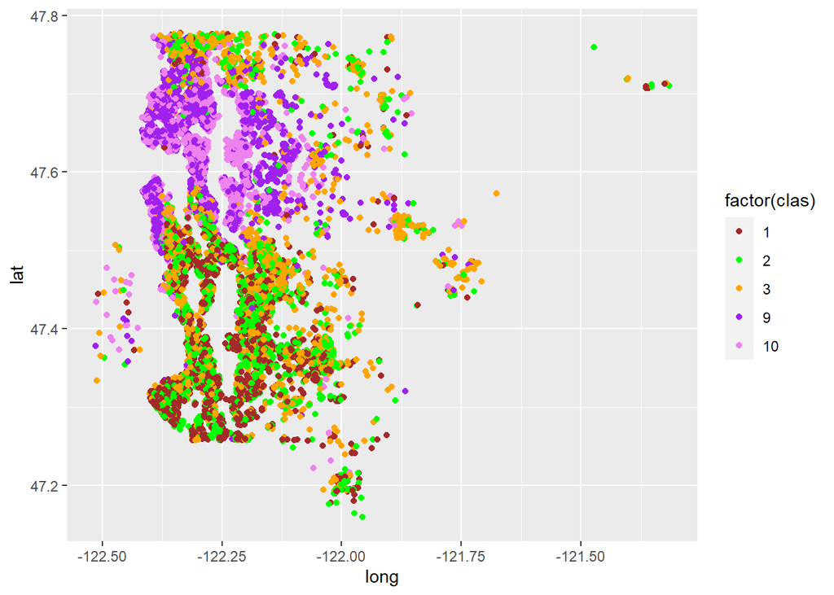

```r
dfq %>%
  select( mt,price, lat, long, zipcode,clas) %>%
  filter(clas<4 | clas>8) %>%
  ggplot() +
  geom_point(aes(x = long, y =lat, color = factor(clas)) )+
  scale_colour_manual(values= c('brown', 'green', 'orange','purple', 'violet', 'pink', 'blue','red', 'yellow', 'black'))
```

La variable waterfront influye en la cotización de las casas más valiosas.

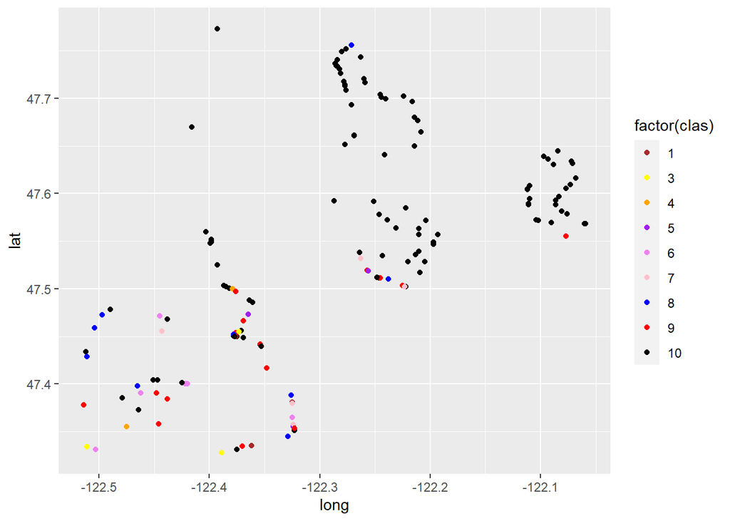

```r
dfq %>%
  select( mt,price, lat, long, zipcode,clas, waterfront) %>%
  filter(waterfront== 1) %>%
  ggplot() +
  geom_point(aes(x = long, y =lat, color = factor(clas)) )+
  scale_colour_manual(values= c('brown', 'yellow', 'orange','purple', 'violet', 'pink', 'blue','red', 'black', 'green'))
```

### Correlación:

Seguimos con las correlaciones entre variables numéricas:

Creo una lista con las covarianzas más relevantes (>50%)

```r
comatriz <- df %>%
  select(where(is.numeric)) %>%
  cor()

inds <- which((abs(comatriz) > 0.50) & (abs(comatriz)!= 1), arr.ind = TRUE)

importantes <- data.frame(Var1 = rownames(comatriz)[inds[, 1]],
                          Var2 = colnames(comatriz)[inds[, 2]],
                          Cor = comatriz[inds]) %>% filter(Var1=="price")

columnas <- c(importantes$Var2, "price", "clas")
vargrafic <- dfq[columnas]
columnas
```

```
## [1] "bathrooms"     "sqft_living"   "grade"         "sqft_above"
## [5] "sqft_living15" "price"         "clas"
```

Las meto en un ggpairs para visualizarlas con sus relaciones.

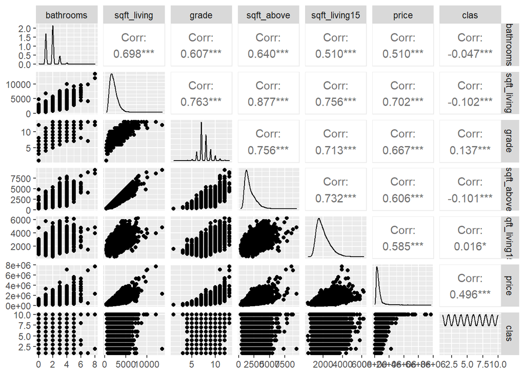

```r
ggpairs(vargrafic)
```

Hago un corrplot para ver las correlaciones graficamente.

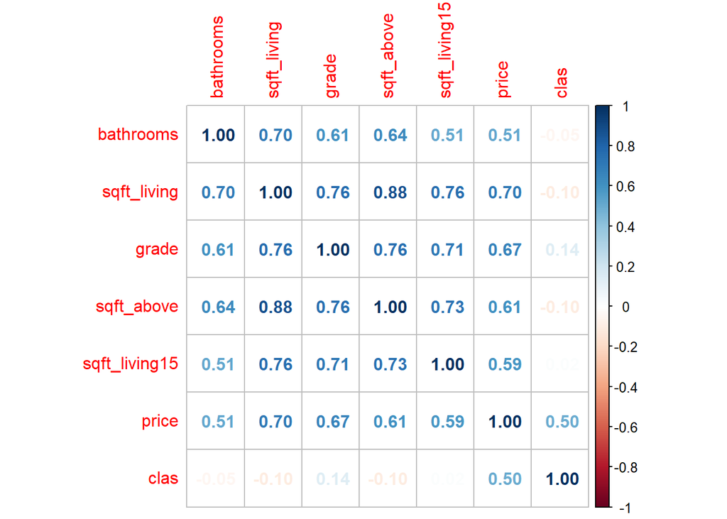

```r
corrplot(vargrafic %>% cor(), method="number")
```

## Outliers y leverage:

Para estudiar los outliers, voy a utilizar las variables categóricas, relacionadas con las dos variables principales, precio y sqft_living.

```r
carac <- df%>% mutate(
  grade = as.factor(grade),
  zipcode = as.factor(zipcode),
  condition = as.factor(condition),
  waterfront = as.factor(waterfront))
```

Incluyo los ids de row en el dataframe para localizar gráficamente los valores a analizar.

```r
carac["index"] <- row.names(carac)
```

Hago un primer gráfico,y teniendo en cuenta que los precios más caros se encuentran habitualmente en la costa, veo que hay que profundizar en los registros 7253, 9255 y 12778. Le echaré un vistazo al 3915. La casa 12778 tiene 7 habitaciones y ocho baños pero su precio es mucho menor que el de la 7253 que también tiene más baños que habitaciones. La número 19453 debe ser un terreno, no tiene habitaciones ni baños, y un precio más bajo.La número 9255, más baños que habitaciones y tiene un precio similar a la 3915 que teniendo una superficie mayor, habiéndose renovado en el año 2001 y estando en la costa tiene un precio parecido.

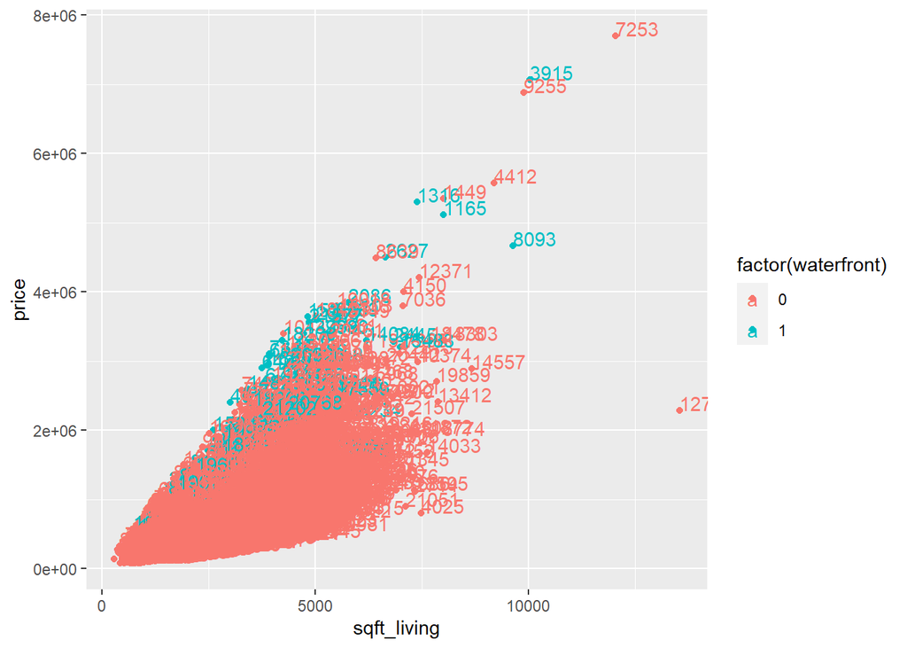

```r
carac %>%
  select(where(is.factor), price, sqft_living, index ) %>%
  ggplot(aes(x = sqft_living, y = price, color = factor(waterfront) ,label = index)) +
  geom_point() +
  geom_text(hjust=0, vjust=0)
```

Voy a utilizar este gráfico sobre este sencillo modelo para visualizar outliers y puntos leverage. Las casas que hemos detallado anteriormente sobrepasan los límites de la distancia de cook y sd.

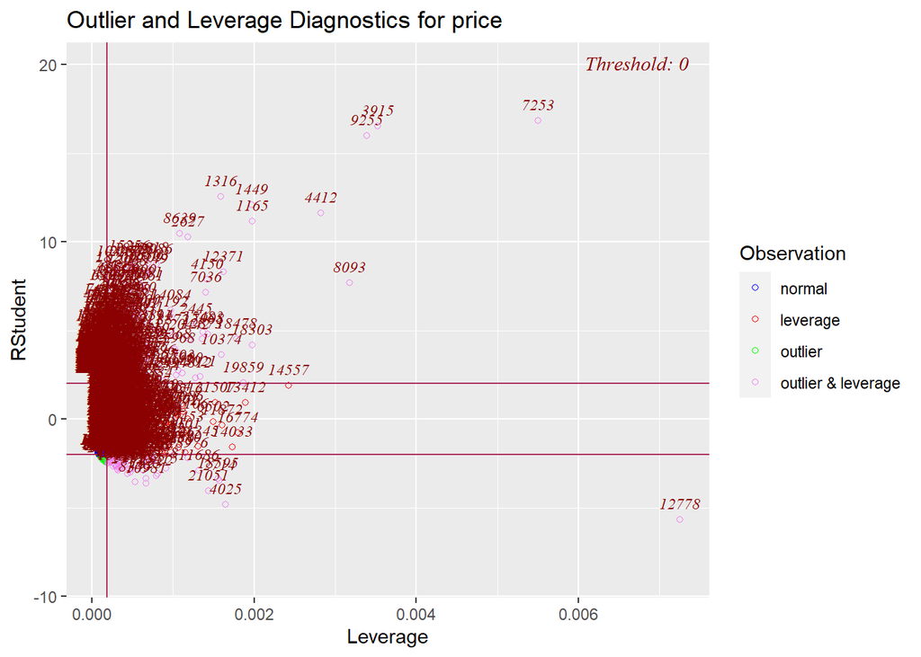

```r
modelier <- lm(price~ sqft_living, data = carac )
ols_plot_resid_lev(modelier)
```

Realizo el modelo sin tocar el dataframe

```r
modelier <- lm(price~ sqft_living + bathrooms  + grade + sqft_above +sqft_living15 , data =carac)
summary(modelier)
```

```
##
## Call:
## lm(formula = price ~ sqft_living + bathrooms + grade + sqft_above +
##     sqft_living15, data = carac)
##
## Residuals:
##      Min       1Q   Median       3Q      Max
## -1559116  -123722   -26644    90363  4767032
##
## Coefficients:
##                 Estimate Std. Error t value Pr(>|t|)
## (Intercept)    6.800e+04  2.345e+05   0.290 0.771867
## sqft_living    2.056e+02  4.228e+00  48.636  < 2e-16 ***
## bathrooms      1.101e+04  3.107e+03   3.543 0.000396 ***
## grade3         4.349e+04  2.707e+05   0.161 0.872375
## grade4         2.940e+04  2.385e+05   0.123 0.901892
## grade5         2.463e+04  2.350e+05   0.105 0.916524
## grade6         4.639e+04  2.346e+05   0.198 0.843213
## grade7         6.676e+04  2.345e+05   0.285 0.775904
## grade8         1.359e+05  2.346e+05   0.579 0.562318
## grade9         2.768e+05  2.347e+05   1.179 0.238233
## grade10        4.814e+05  2.348e+05   2.050 0.040347 *
## grade11        7.817e+05  2.351e+05   3.325 0.000886 ***
## grade12        1.317e+06  2.363e+05   5.574 2.52e-08 ***
## grade13        2.550e+06  2.442e+05  10.442  < 2e-16 ***
## sqft_above    -9.997e+01  4.259e+00 -23.472  < 2e-16 ***
## sqft_living15  2.677e+01  3.856e+00   6.942 3.96e-12 ***
## ---
## Signif. codes:  0 '***' 0.001 '**' 0.01 '*' 0.05 '.' 0.1 ' ' 1
##
## Residual standard error: 234500 on 21597 degrees of freedom
## Multiple R-squared:  0.5924, Adjusted R-squared:  0.5921
## F-statistic:  2093 on 15 and 21597 DF,  p-value: < 2.2e-16
```

Elimino las observaciones problemáticas.

```r
carac_sin <- carac[-c(12778, 19453, 7253, 3915),]
modelier <- lm(price~ sqft_living + bathrooms  + grade + sqft_above +sqft_living15 , data =carac_sin)
summary(modelier)
```

```
##
## Call:
## lm(formula = price ~ sqft_living + bathrooms + grade + sqft_above +
##     sqft_living15, data = carac_sin)
##
## Residuals:
##      Min       1Q   Median       3Q      Max
## -1561984  -123939   -26760    90099  3207105
##
## Coefficients:
##                 Estimate Std. Error t value Pr(>|t|)
## (Intercept)    1.116e+05  1.334e+05   0.836 0.402944
## sqft_living    1.995e+02  4.185e+00  47.677  < 2e-16 ***
## bathrooms      1.209e+04  3.061e+03   3.949 7.88e-05 ***
## grade4        -1.545e+04  1.401e+05  -0.110 0.912138
## grade5        -1.814e+04  1.342e+05  -0.135 0.892479
## grade6         4.842e+03  1.334e+05   0.036 0.971053
## grade7         2.706e+04  1.334e+05   0.203 0.839283
## grade8         9.772e+04  1.335e+05   0.732 0.464118
## grade9         2.410e+05  1.336e+05   1.803 0.071347 .
## grade10        4.480e+05  1.338e+05   3.348 0.000816 ***
## grade11        7.398e+05  1.344e+05   5.506 3.71e-08 ***
## grade12        1.305e+06  1.363e+05   9.570  < 2e-16 ***
## grade13        2.263e+06  1.502e+05  15.060  < 2e-16 ***
## sqft_above    -1.006e+02  4.195e+00 -23.978  < 2e-16 ***
## sqft_living15  3.015e+01  3.803e+00   7.928 2.34e-15 ***
## ---
## Signif. codes:  0 '***' 0.001 '**' 0.01 '*' 0.05 '.' 0.1 ' ' 1
##
## Residual standard error: 230900 on 21594 degrees of freedom
## Multiple R-squared:  0.5911, Adjusted R-squared:  0.5909
## F-statistic:  2230 on 14 and 21594 DF,  p-value: < 2.2e-16
```

Lo cierto es que el R2 ajustado disminuye en este modelo quitando estas casas. Seguiremos con el dataframe original.`

# MODELOS

## Primeros modelos:

```r
#convierto en nominales estas variables
dfq <- df%>% mutate(
  grade = as.factor(grade),
  zipcode = as.factor(zipcode),
  condition = as.factor(condition),
  waterfront = as.factor(waterfront))

modelo <- lm(price~ sqft_living + bathrooms  +  sqft_above +sqft_living15 , data =dfq)
summary(modelo)
```

```
##
## Call:
## lm(formula = price ~ sqft_living + bathrooms + sqft_above + sqft_living15,
##     data = dfq)
##
## Residuals:
##      Min       1Q   Median       3Q      Max
## -1252829  -146420   -22527   106227  4583775
##
## Coefficients:
##                 Estimate Std. Error t value Pr(>|t|)
## (Intercept)   -1.148e+05  5.801e+03 -19.786  < 2e-16 ***
## sqft_living    2.554e+02  4.574e+00  55.834  < 2e-16 ***
## bathrooms      2.461e+04  3.364e+03   7.317 2.62e-13 ***
## sqft_above    -4.042e+01  4.549e+00  -8.884  < 2e-16 ***
## sqft_living15  7.699e+01  4.033e+00  19.090  < 2e-16 ***
## ---
## Signif. codes:  0 '***' 0.001 '**' 0.01 '*' 0.05 '.' 0.1 ' ' 1
##
## Residual standard error: 259000 on 21608 degrees of freedom
## Multiple R-squared:  0.5026, Adjusted R-squared:  0.5025
## F-statistic:  5457 on 4 and 21608 DF,  p-value: < 2.2e-16
```

Nos sale un F adecuado, todas las variables son significativas, pero el R ajustado es un 50%. Ahora vamos a transformar la variable objetivo y tambien la variable independiente sqft_living

```r
modelo <- lm(log(price)~ log(sqft_living)+ bathrooms  +  sqft_above +sqft_living15, data =dfq )
summary(modelo)
```

```
##
## Call:
## lm(formula = log(price) ~ log(sqft_living) + bathrooms + sqft_above +
##     sqft_living15, data = dfq)
##
## Residuals:
##      Min       1Q   Median       3Q      Max
## -1.29966 -0.28408  0.00572  0.25983  1.34843
##
## Coefficients:
##                   Estimate Std. Error t value Pr(>|t|)
## (Intercept)      8.655e+00  8.032e-02 107.763   <2e-16 ***
## log(sqft_living) 5.121e-01  1.220e-02  41.985   <2e-16 ***
## bathrooms        6.741e-02  4.804e-03  14.032   <2e-16 ***
## sqft_above       3.195e-06  5.969e-06   0.535    0.592
## sqft_living15    2.024e-04  5.807e-06  34.861   <2e-16 ***
## ---
## Signif. codes:  0 '***' 0.001 '**' 0.01 '*' 0.05 '.' 0.1 ' ' 1
##
## Residual standard error: 0.375 on 21608 degrees of freedom
## Multiple R-squared:  0.493,  Adjusted R-squared:  0.4929
## F-statistic:  5253 on 4 and 21608 DF,  p-value: < 2.2e-16
```

Lo cierto es que la R ha descendido

Como hemos visto antes en la EDA que la localización de la casa puede ser importante, incluimos también la longitud y la latitud

```r
modelo <- lm(log(price)~ log(sqft_living)+ lat*long+ bathrooms  + grade  + sqft_above +sqft_living15 , data = dfq )
summary(modelo)
```

```
##
## Call:
## lm(formula = log(price) ~ log(sqft_living) + lat * long + bathrooms +
##     grade + sqft_above + sqft_living15, data = dfq)
##
## Residuals:
##      Min       1Q   Median       3Q      Max
## -1.29206 -0.17703 -0.00951  0.16730  1.25756
##
## Coefficients:
##                    Estimate Std. Error t value Pr(>|t|)
## (Intercept)       1.568e+04  6.033e+02  25.992  < 2e-16 ***
## log(sqft_living)  4.253e-01  9.685e-03  43.913  < 2e-16 ***
## lat              -3.305e+02  1.269e+01 -26.050  < 2e-16 ***
## long              1.288e+02  4.937e+00  26.089  < 2e-16 ***
## bathrooms         1.920e-02  3.613e-03   5.313 1.09e-07 ***
## grade3            1.232e-01  3.191e-01   0.386 0.699481
## grade4           -3.130e-02  2.810e-01  -0.111 0.911327
## grade5           -6.661e-02  2.770e-01  -0.240 0.809963
## grade6           -1.334e-02  2.766e-01  -0.048 0.961521
## grade7            6.908e-02  2.766e-01   0.250 0.802778
## grade8            2.046e-01  2.767e-01   0.739 0.459688
## grade9            3.795e-01  2.768e-01   1.371 0.170266
## grade10           5.459e-01  2.769e-01   1.972 0.048672 *
## grade11           7.125e-01  2.773e-01   2.570 0.010183 *
## grade12           9.493e-01  2.786e-01   3.407 0.000657 ***
## grade13           1.210e+00  2.879e-01   4.202 2.65e-05 ***
## sqft_above       -1.754e-05  4.957e-06  -3.539 0.000403 ***
## sqft_living15     1.254e-04  4.666e-06  26.880  < 2e-16 ***
## lat:long         -2.716e+00  1.038e-01 -26.163  < 2e-16 ***
## ---
## Signif. codes:  0 '***' 0.001 '**' 0.01 '*' 0.05 '.' 0.1 ' ' 1
##
## Residual standard error: 0.2762 on 21594 degrees of freedom
## Multiple R-squared:  0.7252, Adjusted R-squared:  0.725
## F-statistic:  3166 on 18 and 21594 DF,  p-value: < 2.2e-16
```

Damos un salto importante hasta el 72% de R hacemos un check_model para ver por donde vamos.

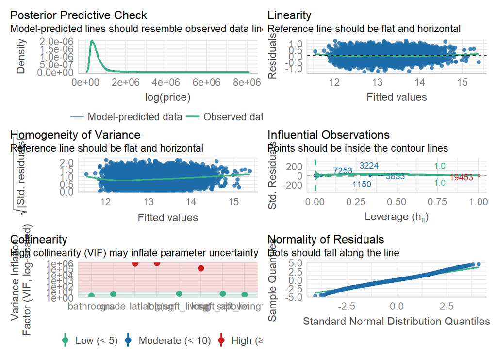

```r
check_model(modelo)
```

Hay colinearidad, según el gráfico. No hay normalidad en los residuos

```r
moments::jarque.test(modelo$residuals)
```

```
##
##  Jarque-Bera Normality Test
##
## data:  modelo$residuals
## JB = 561.11, p-value < 2.2e-16
## alternative hypothesis: greater
```

Tenemos heterocedasticidad.

```r
lmtest::bptest(modelo)
```

```
##
##  studentized Breusch-Pagan test
##
## data:  modelo
## BP = 1408.3, df = 18, p-value < 2.2e-16
```

## Modelo con dummies:

Ahora lo que voy a hacer es crear dummies con el campo zipcode, para ver si podemos mejorar el modelo.

```r
dfdummy <- dummy_cols(df, select_columns = 'zipcode')
```

Con este modelo que incluye lat y long, el VIF se dispara

```r
datando <- dfdummy %>% select(contains('zipcode_'), price, grade, sqft_living, lat, long)
#quito una columna para no caer en la Dummy Trap
datando <- subset(datando, select=-c(zipcode_98001))
modelo <- lm(log(price) ~ ., data = datando, na.action = na.exclude)
summary(modelo)
```

```
##
## Call:
## lm(formula = log(price) ~ ., data = datando, na.action = na.exclude)
##
## Residuals:
##      Min       1Q   Median       3Q      Max
## -1.81872 -0.11071  0.00111  0.10743  1.32199
##
## Coefficients:
##                 Estimate Std. Error t value Pr(>|t|)
## (Intercept)   -5.455e+01  7.898e+00  -6.907 5.08e-12 ***
## zipcode_98002  1.847e-03  1.866e-02   0.099  0.92116
## zipcode_98003 -3.102e-03  1.671e-02  -0.186  0.85270
## zipcode_98004  1.031e+00  3.030e-02  34.019  < 2e-16 ***
## zipcode_98005  6.837e-01  3.238e-02  21.116  < 2e-16 ***
## zipcode_98006  6.229e-01  2.641e-02  23.584  < 2e-16 ***
## zipcode_98007  5.946e-01  3.342e-02  17.793  < 2e-16 ***
## zipcode_98008  6.416e-01  3.170e-02  20.238  < 2e-16 ***
## zipcode_98010  3.891e-01  2.849e-02  13.658  < 2e-16 ***
## zipcode_98011  3.093e-01  4.136e-02   7.479 7.78e-14 ***
## zipcode_98014  3.788e-01  4.537e-02   8.350  < 2e-16 ***
## zipcode_98019  3.029e-01  4.477e-02   6.765 1.37e-11 ***
## zipcode_98022  2.841e-01  2.470e-02  11.506  < 2e-16 ***
## zipcode_98023 -6.813e-02  1.536e-02  -4.434 9.30e-06 ***
## zipcode_98024  5.403e-01  3.984e-02  13.564  < 2e-16 ***
## zipcode_98027  5.257e-01  2.716e-02  19.351  < 2e-16 ***
## zipcode_98028  2.669e-01  4.017e-02   6.645 3.11e-11 ***
## zipcode_98029  5.886e-01  3.100e-02  18.990  < 2e-16 ***
## zipcode_98030  5.943e-02  1.837e-02   3.236  0.00122 **
## zipcode_98031  7.507e-02  1.910e-02   3.930 8.51e-05 ***
## zipcode_98032 -6.304e-02  2.220e-02  -2.840  0.00451 **
## zipcode_98033  6.893e-01  3.443e-02  20.020  < 2e-16 ***
## zipcode_98034  4.185e-01  3.693e-02  11.332  < 2e-16 ***
## zipcode_98038  2.478e-01  2.057e-02  12.047  < 2e-16 ***
## zipcode_98039  1.162e+00  4.097e-02  28.361  < 2e-16 ***
## zipcode_98040  8.589e-01  2.670e-02  32.164  < 2e-16 ***
## zipcode_98042  1.140e-01  1.755e-02   6.496 8.42e-11 ***
## zipcode_98045  4.912e-01  3.806e-02  12.907  < 2e-16 ***
## zipcode_98052  5.578e-01  3.514e-02  15.873  < 2e-16 ***
## zipcode_98053  5.456e-01  3.767e-02  14.484  < 2e-16 ***
```

[output cut: 35 more lines]

```
## zipcode_98177  4.322e-01  3.938e-02  10.974  < 2e-16 ***
## zipcode_98178  1.025e-01  2.306e-02   4.444 8.89e-06 ***
## zipcode_98188  2.511e-02  2.376e-02   1.057  0.29065
## zipcode_98198  5.241e-02  1.797e-02   2.916  0.00355 **
## zipcode_98199  6.798e-01  3.244e-02  20.955  < 2e-16 ***
## grade          1.073e-01  1.975e-03  54.318  < 2e-16 ***
## sqft_living    2.491e-04  2.456e-06 101.444  < 2e-16 ***
## lat            3.633e-01  8.181e-02   4.441 8.99e-06 ***
## long          -3.975e-01  5.854e-02  -6.790 1.15e-11 ***
## ---
## Signif. codes:  0 '***' 0.001 '**' 0.01 '*' 0.05 '.' 0.1 ' ' 1
##
## Residual standard error: 0.2078 on 21539 degrees of freedom
## Multiple R-squared:  0.8448, Adjusted R-squared:  0.8443
## F-statistic:  1606 on 73 and 21539 DF,  p-value: < 2.2e-16
```

```r
vif(modelo)
```

```
## zipcode_98002 zipcode_98003 zipcode_98004 zipcode_98005 zipcode_98006
##      1.589870      1.786372      6.641132      4.045624      7.858204
## zipcode_98007 zipcode_98008 zipcode_98010 zipcode_98011 zipcode_98014
##      3.621700      6.498285      1.869907      7.651909      5.876206
## zipcode_98019 zipcode_98022 zipcode_98023 zipcode_98024 zipcode_98027
##      8.739205      3.268194      2.664385      2.964715      6.904460
## zipcode_98028 zipcode_98029 zipcode_98030 zipcode_98031 zipcode_98032
##     10.431610      7.033742      1.976007      2.285293      1.417567
## zipcode_98033 zipcode_98034 zipcode_98038 zipcode_98039 zipcode_98040
##     11.619112     16.770955      5.623391      1.938868      4.594638
## zipcode_98042 zipcode_98045 zipcode_98052 zipcode_98053 zipcode_98055
##      3.808244      7.333907     15.974321     13.057665      2.775603
## zipcode_98056 zipcode_98058 zipcode_98059 zipcode_98065 zipcode_98070
##      4.918681      4.170808      5.443232      8.658013      1.842272
## zipcode_98072 zipcode_98074 zipcode_98075 zipcode_98077 zipcode_98092
##     10.558768     11.066188      8.337534      8.307137      2.230159
## zipcode_98102 zipcode_98103 zipcode_98105 zipcode_98106 zipcode_98107
##      2.997955     14.808013      6.046864      4.631469      7.087877
## zipcode_98108 zipcode_98109 zipcode_98112 zipcode_98115 zipcode_98116
##      3.152382      3.098771      5.942411     14.936129      5.641446
## zipcode_98117 zipcode_98118 zipcode_98119 zipcode_98122 zipcode_98125
##     14.542129      6.579544      4.639203      5.779602     12.420265
## zipcode_98126 zipcode_98133 zipcode_98136 zipcode_98144 zipcode_98146
##      5.111218     15.894439      4.007402      5.917410      3.515884
## zipcode_98148 zipcode_98155 zipcode_98166 zipcode_98168 zipcode_98177
##      1.308993     15.578799      2.595719      3.076104      9.048808
## zipcode_98178 zipcode_98188 zipcode_98198 zipcode_98199         grade
##      3.186056      1.766481      2.066326      7.611619      2.696381
##   sqft_living           lat          long
##      2.545546     64.293936     34.003703
```

Podemos observar los valores de VIF para latitud y longitud .

Con este nuevo modelo, los valores de colinearidad se contienen y el R se mantiene.

```r
datando <- dfdummy %>% select(contains('zipcode_'), price, grade, sqft_living)
datando <- subset(datando, select=-c(zipcode_98001))
modelo <- lm(log(price) ~ ., data = datando, na.action = na.exclude)
summary(modelo)
```

```
##
## Call:
## lm(formula = log(price) ~ ., data = datando, na.action = na.exclude)
##
## Residuals:
##      Min       1Q   Median       3Q      Max
## -1.83334 -0.11033  0.00046  0.10795  1.32276
##
## Coefficients:
##                 Estimate Std. Error t value Pr(>|t|)
## (Intercept)    1.123e+01  1.590e-02 706.448  < 2e-16 ***
## zipcode_98002 -2.093e-02  1.839e-02  -1.138 0.255144
## zipcode_98003  1.492e-02  1.657e-02   0.900 0.367907
## zipcode_98004  1.117e+00  1.613e-02  69.204  < 2e-16 ***
## zipcode_98005  7.525e-01  1.950e-02  38.583  < 2e-16 ***
## zipcode_98006  6.642e-01  1.453e-02  45.716  < 2e-16 ***
## zipcode_98007  6.529e-01  2.069e-02  31.564  < 2e-16 ***
## zipcode_98008  6.906e-01  1.652e-02  41.793  < 2e-16 ***
## zipcode_98010  2.901e-01  2.352e-02  12.336  < 2e-16 ***
## zipcode_98011  4.438e-01  1.850e-02  23.985  < 2e-16 ***
## zipcode_98014  3.428e-01  2.166e-02  15.826  < 2e-16 ***
## zipcode_98019  3.329e-01  1.865e-02  17.847  < 2e-16 ***
## zipcode_98022  1.392e-01  1.746e-02   7.972 1.64e-15 ***
## zipcode_98023 -3.111e-02  1.438e-02  -2.164 0.030476 *
## zipcode_98024  4.859e-01  2.560e-02  18.981  < 2e-16 ***
## zipcode_98027  5.124e-01  1.505e-02  34.049  < 2e-16 ***
## zipcode_98028  4.192e-01  1.652e-02  25.371  < 2e-16 ***
## zipcode_98029  5.741e-01  1.604e-02  35.785  < 2e-16 ***
## zipcode_98030  4.933e-02  1.700e-02   2.902 0.003712 **
## zipcode_98031  7.713e-02  1.667e-02   4.627 3.73e-06 ***
## zipcode_98032 -3.637e-02  2.160e-02  -1.684 0.092227 .
## zipcode_98033  7.911e-01  1.487e-02  53.195  < 2e-16 ***
## zipcode_98034  5.428e-01  1.412e-02  38.452  < 2e-16 ***
## zipcode_98038  1.753e-01  1.390e-02  12.606  < 2e-16 ***
## zipcode_98039  1.263e+00  3.159e-02  39.963  < 2e-16 ***
## zipcode_98040  9.321e-01  1.670e-02  55.808  < 2e-16 ***
## zipcode_98042  7.289e-02  1.410e-02   5.170 2.36e-07 ***
## zipcode_98045  3.475e-01  1.778e-02  19.550  < 2e-16 ***
## zipcode_98052  6.325e-01  1.403e-02  45.095  < 2e-16 ***
## zipcode_98053  5.819e-01  1.512e-02  38.480  < 2e-16 ***
```

[output cut: 33 more lines]

```
## zipcode_98166  3.695e-01  1.704e-02  21.685  < 2e-16 ***
## zipcode_98168  4.522e-02  1.679e-02   2.693 0.007083 **
## zipcode_98177  6.288e-01  1.704e-02  36.893  < 2e-16 ***
## zipcode_98178  1.622e-01  1.690e-02   9.599  < 2e-16 ***
## zipcode_98188  7.951e-02  2.094e-02   3.797 0.000147 ***
## zipcode_98198  1.000e-01  1.657e-02   6.037 1.59e-09 ***
## zipcode_98199  8.537e-01  1.605e-02  53.201  < 2e-16 ***
## grade          1.077e-01  1.977e-03  54.445  < 2e-16 ***
## sqft_living    2.486e-04  2.459e-06 101.096  < 2e-16 ***
## ---
## Signif. codes:  0 '***' 0.001 '**' 0.01 '*' 0.05 '.' 0.1 ' ' 1
##
## Residual standard error: 0.2082 on 21541 degrees of freedom
## Multiple R-squared:  0.8443, Adjusted R-squared:  0.8438
## F-statistic:  1645 on 71 and 21541 DF,  p-value: < 2.2e-16
```

Los valores de colinearidad son asumibles.

```r
vif(modelo)
```

```
## zipcode_98002 zipcode_98003 zipcode_98004 zipcode_98005 zipcode_98006
##      1.538733      1.751752      1.876468      1.463179      2.369793
## zipcode_98007 zipcode_98008 zipcode_98010 zipcode_98011 zipcode_98014
##      1.383395      1.760030      1.270818      1.526883      1.335348
## zipcode_98019 zipcode_98022 zipcode_98023 zipcode_98024 zipcode_98027
##      1.512402      1.628779      2.325563      1.220384      2.112017
## zipcode_98028 zipcode_98029 zipcode_98030 zipcode_98031 zipcode_98032
##      1.759716      1.878249      1.687118      1.734728      1.337746
## zipcode_98033 zipcode_98034 zipcode_98038 zipcode_98039 zipcode_98040
##      2.160867      2.443521      2.560745      1.149117      1.791866
## zipcode_98042 zipcode_98045 zipcode_98052 zipcode_98053 zipcode_98055
##      2.450470      1.595022      2.536815      2.097354      1.719083
## zipcode_98056 zipcode_98058 zipcode_98059 zipcode_98065 zipcode_98070
##      2.082129      2.210784      2.251909      1.839049      1.318736
## zipcode_98072 zipcode_98074 zipcode_98075 zipcode_98077 zipcode_98092
##      1.739069      2.211055      2.004703      1.552023      1.942332
## zipcode_98102 zipcode_98103 zipcode_98105 zipcode_98106 zipcode_98107
##      1.289694      2.597314      1.618346      1.899485      1.719394
## zipcode_98108 zipcode_98109 zipcode_98112 zipcode_98115 zipcode_98116
##      1.501445      1.298070      1.736828      2.541043      1.885402
## zipcode_98117 zipcode_98118 zipcode_98119 zipcode_98122 zipcode_98125
##      2.465994      2.349167      1.502171      1.785083      2.092810
## zipcode_98126 zipcode_98133 zipcode_98136 zipcode_98144 zipcode_98146
##      1.948602      2.313589      1.707662      1.917287      1.774431
## zipcode_98148 zipcode_98155 zipcode_98166 zipcode_98168 zipcode_98177
##      1.154771      2.186391      1.682192      1.728598      1.689449
## zipcode_98178 zipcode_98188 zipcode_98198 zipcode_98199         grade
##      1.705853      1.367480      1.751027      1.856223      2.694829
##   sqft_living
##      2.543750
```

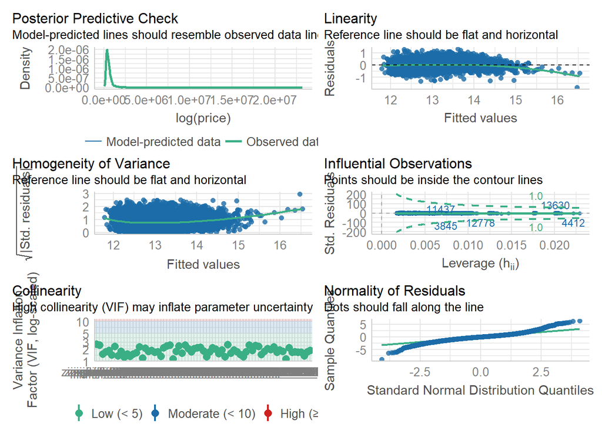

```r
check_model(modelo)
```

Parece que waterfront y condition también aportan al modelo. R sube ligeramente, puede ser por la adición de nuevas variables.

```r
datando <- dfdummy %>% select(contains('zipcode_'), price, grade, waterfront, condition, sqft_living)
datando <- subset(datando, select=-c(zipcode_98001))
modelo <- lm(log(price) ~ ., data = datando, na.action = na.exclude)
```

Se ha llegado a un buen R ajustado. Casi todas las variables aportan al modelo.

```r
summary(modelo)
```

```
##
## Call:
## lm(formula = log(price) ~ ., data = datando, na.action = na.exclude)
##
## Residuals:
##      Min       1Q   Median       3Q      Max
## -1.73325 -0.10619  0.00377  0.10905  1.21289
##
## Coefficients:
##                 Estimate Std. Error t value Pr(>|t|)
## (Intercept)    1.101e+01  1.771e-02 621.452  < 2e-16 ***
## zipcode_98002 -4.363e-02  1.744e-02  -2.502  0.01236 *
## zipcode_98003  1.142e-02  1.570e-02   0.727  0.46713
## zipcode_98004  1.106e+00  1.530e-02  72.314  < 2e-16 ***
## zipcode_98005  7.312e-01  1.851e-02  39.504  < 2e-16 ***
## zipcode_98006  6.402e-01  1.380e-02  46.386  < 2e-16 ***
## zipcode_98007  6.339e-01  1.962e-02  32.313  < 2e-16 ***
## zipcode_98008  6.503e-01  1.568e-02  41.465  < 2e-16 ***
## zipcode_98010  2.807e-01  2.229e-02  12.592  < 2e-16 ***
## zipcode_98011  4.512e-01  1.753e-02  25.732  < 2e-16 ***
## zipcode_98014  3.555e-01  2.053e-02  17.313  < 2e-16 ***
## zipcode_98019  3.499e-01  1.768e-02  19.788  < 2e-16 ***
## zipcode_98022  1.162e-01  1.657e-02   7.015 2.37e-12 ***
## zipcode_98023 -4.031e-02  1.363e-02  -2.958  0.00310 **
## zipcode_98024  4.952e-01  2.426e-02  20.412  < 2e-16 ***
## zipcode_98027  5.068e-01  1.426e-02  35.534  < 2e-16 ***
## zipcode_98028  4.193e-01  1.566e-02  26.779  < 2e-16 ***
## zipcode_98029  5.820e-01  1.520e-02  38.287  < 2e-16 ***
## zipcode_98030  5.200e-02  1.611e-02   3.228  0.00125 **
## zipcode_98031  6.726e-02  1.580e-02   4.257 2.08e-05 ***
## zipcode_98032 -5.450e-02  2.047e-02  -2.662  0.00777 **
## zipcode_98033  7.760e-01  1.410e-02  55.036  < 2e-16 ***
## zipcode_98034  5.325e-01  1.338e-02  39.799  < 2e-16 ***
## zipcode_98038  1.844e-01  1.318e-02  13.990  < 2e-16 ***
## zipcode_98039  1.246e+00  2.994e-02  41.615  < 2e-16 ***
## zipcode_98040  8.793e-01  1.588e-02  55.360  < 2e-16 ***
## zipcode_98042  6.219e-02  1.337e-02   4.652 3.30e-06 ***
## zipcode_98045  3.581e-01  1.685e-02  21.257  < 2e-16 ***
## zipcode_98052  6.287e-01  1.329e-02  47.300  < 2e-16 ***
## zipcode_98053  5.992e-01  1.434e-02  41.799  < 2e-16 ***
```

[output cut: 35 more lines]

```
## zipcode_98177  6.168e-01  1.616e-02  38.175  < 2e-16 ***
## zipcode_98178  1.423e-01  1.603e-02   8.877  < 2e-16 ***
## zipcode_98188  8.064e-02  1.984e-02   4.064 4.84e-05 ***
## zipcode_98198  7.008e-02  1.571e-02   4.460 8.24e-06 ***
## zipcode_98199  8.393e-01  1.522e-02  55.162  < 2e-16 ***
## grade          1.149e-01  1.904e-03  60.363  < 2e-16 ***
## waterfront     6.536e-01  1.597e-02  40.926  < 2e-16 ***
## condition      5.896e-02  2.169e-03  27.180  < 2e-16 ***
## sqft_living    2.373e-04  2.343e-06 101.279  < 2e-16 ***
## ---
## Signif. codes:  0 '***' 0.001 '**' 0.01 '*' 0.05 '.' 0.1 ' ' 1
##
## Residual standard error: 0.1972 on 21539 degrees of freedom
## Multiple R-squared:  0.8602, Adjusted R-squared:  0.8597
## F-statistic:  1816 on 73 and 21539 DF,  p-value: < 2.2e-16
```

Tenemos heterocedasticidad.

```r
lmtest::bptest(modelo)
```

```
##
##  studentized Breusch-Pagan test
##
## data:  modelo
## BP = 1043.1, df = 73, p-value < 2.2e-16
```

No hay normalidad en los residuos.

```r
moments::jarque.test(modelo$residuals)
```

```
##
##  Jarque-Bera Normality Test
##
## data:  modelo$residuals
## JB = 6488.8, p-value < 2.2e-16
## alternative hypothesis: greater
```

Aunque el gráfico de los residuos parece bastante simétrico.

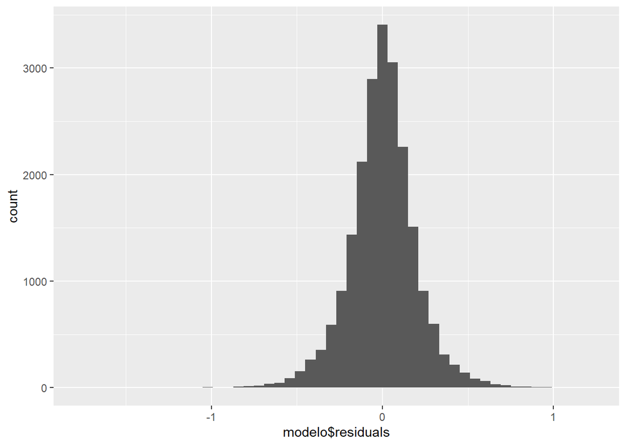

```r
ggplot(data = modelo , aes(x = modelo$residuals)) +
  geom_histogram(bins = 50)
```

No hay colinearidad.

```r
vif(modelo)
```

```
## zipcode_98002 zipcode_98003 zipcode_98004 zipcode_98005 zipcode_98006
##      1.541502      1.751916      1.879593      1.467796      2.382315
## zipcode_98007 zipcode_98008 zipcode_98010 zipcode_98011 zipcode_98014
##      1.385743      1.765932      1.271244      1.527041      1.335889
## zipcode_98019 zipcode_98022 zipcode_98023 zipcode_98024 zipcode_98027
##      1.513897      1.632800      2.326108      1.220506      2.112855
## zipcode_98028 zipcode_98029 zipcode_98030 zipcode_98031 zipcode_98032
##      1.759720      1.878488      1.687158      1.735708      1.338984
## zipcode_98033 zipcode_98034 zipcode_98038 zipcode_98039 zipcode_98040
##      2.163449      2.444136      2.561784      1.149712      1.804924
## zipcode_98042 zipcode_98045 zipcode_98052 zipcode_98053 zipcode_98055
##      2.452896      1.595654      2.537249      2.099341      1.719110
## zipcode_98056 zipcode_98058 zipcode_98059 zipcode_98065 zipcode_98070
##      2.088819      2.212111      2.252617      1.841799      1.352102
## zipcode_98072 zipcode_98074 zipcode_98075 zipcode_98077 zipcode_98092
##      1.739209      2.211291      2.005159      1.552773      1.942438
## zipcode_98102 zipcode_98103 zipcode_98105 zipcode_98106 zipcode_98107
##      1.290044      2.599801      1.621844      1.900084      1.719970
## zipcode_98108 zipcode_98109 zipcode_98112 zipcode_98115 zipcode_98116
##      1.501491      1.298813      1.739857      2.543585      1.887339
## zipcode_98117 zipcode_98118 zipcode_98119 zipcode_98122 zipcode_98125
##      2.469131      2.349561      1.502612      1.785167      2.093741
## zipcode_98126 zipcode_98133 zipcode_98136 zipcode_98144 zipcode_98146
##      1.949257      2.316039      1.708608      1.918824      1.776600
## zipcode_98148 zipcode_98155 zipcode_98166 zipcode_98168 zipcode_98177
##      1.155368      2.187854      1.689202      1.729617      1.690959
## zipcode_98178 zipcode_98188 zipcode_98198 zipcode_98199         grade
##      1.708390      1.367504      1.753840      1.858710      2.781125
##    waterfront     condition   sqft_living
##      1.060623      1.106850      2.571826
```

[figure not shown]

[output not shown]

[output not shown]

```r
check_model(modelo)
```